# TP-EDO: Résolution Numérique

# Programmation de la méthode d'Euler explicite: y[n+1]=y[n]+h(f(t[n],y[n]))

```python
# IMPORTER LES LIBRAIRIES
import numpy as np
import matplotlib.pyplot as plt
```

Soit le shéma suivant (1): y′(t) = −ky(t) + r, y(t0) = y0. sur l’intervalle de temps [t0, tf ], avec t0 ∈ R et tf > t0, k > 0, r ∈ R, y0 ∈ R. On cherche a obtenir une approximation (yn)0≤n≤N des valeurs y(tn)0≤n≤N prises par la solution exacte y du probleme (1) aux instants ti = t0 + i∆t , ou ∆t est le pas de temps ∆t = (tf − t0)/N. On notera h ou ∆x pour le pas d’espace.

# 1_a) Création du la fonction d'Euler explicite

```python
# Définition du la solution numérique

def Solution(k,r,t0,tf,y0,N):
    t=np.linspace(t0,tf,N) # la subdivision de l'intervalle de temps, de t0 à tf avec un pas N
    y=np.zeros(N) #initialisation du vecteur solution
    y[0]=y0 #condition initiale
    dt=(tf-t0)/(N-1) #longueur du pas de temps
    for i in range(1,N):
        y[i]=y[i-1]+dt*(-k*y[i-1]+r) #schéma d'Euler explicite
    return t,y

# Définition de la solution exacte

def Sol_exacte(k,r,t0,tf,y0,N): #solution exacte de l'équation
    t=np.linspace(t0,tf,N)
    return (y0-r/k)*np.exp(-k*t)+r/k
```

# 1_b) Tracer sur un même graphe la solution exacte et l’approximation obtenue

On fixe k = 150, r = 0, y0 = 1 et [t0, tf ] = [0, 1]. La solution exacte de (1) est donc y(t) = exp(−150t). Tracer sur un mˆeme graphe la solution exacte et l’approximation obtenue

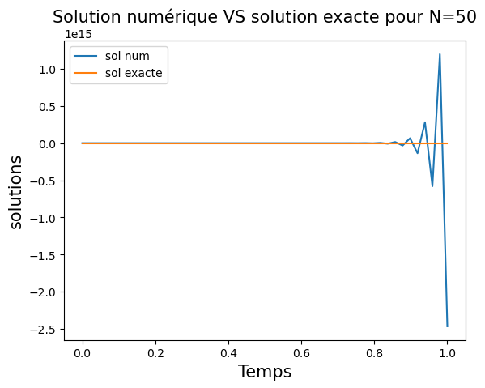

```python
# Initialisation
k = 150
r = 0
y0 = 1
t0= 0
tf= 1
N=50
t=np.linspace(t0,tf,N) # la subdivision de l'intervalle de temps
def Solution(k,r,t0,tf,y0,N):
    y=np.zeros(N) #initialisation du vecteur solution
    y[0]=y0 #condition initiale
    dt=(tf-t0)/(N-1) #longueur du pas de temps
    for i in range(1,N):
        y[i]=y[i-1]+dt*(-k*y[i-1]+r) #schéma d'Euler explicite
    return t,y

# Définition de la solution exacte

def Sol_exacte(k,r,t0,tf,y0,N):
    return (y0-r/k)*np.exp(-k*t)+r/k

# Définition de l'ordonnée du graphe de la solution exacte

y2=Sol_exacte(k,r,t0,tf,y0,N)

# Définition de l'ordonnée et l'abscisse du graphe de la solution numérique

t1,y1=Solution(k,r,t0,tf,y0,N)

plt.figure()
plt.plot(t1,y1,label="sol num")
plt.plot(t,y2,label="sol exacte")
plt.xlabel('Temps',size=15)
plt.ylabel('solutions',size=15)
plt.title('Solution numérique VS solution exacte pour N='+str(N),size=15)
plt.legend()
```

# Test pour deltat=1/70

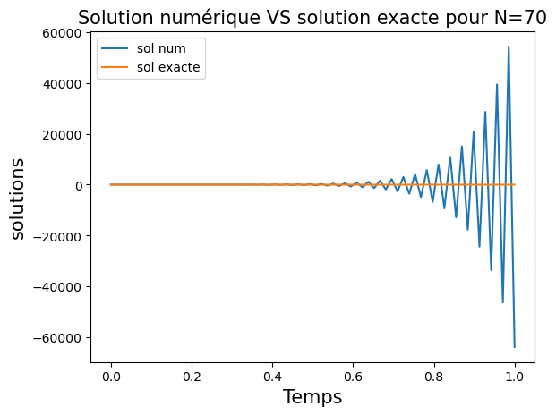

```python
# Initialisation
k = 150
r = 0
y0 = 1
t0= 0
tf= 1
N=70
t=np.linspace(t0,tf,N) # la subdivision de l'intervalle de temps
def Solution(k,r,t0,tf,y0,N):
    y=np.zeros(N) #initialisation du vecteur solution
    y[0]=y0 #condition initiale
    dt=(tf-t0)/(N-1) #longueur du pas de temps
    for i in range(1,N):
        y[i]=y[i-1]+dt*(-k*y[i-1]+r) #schéma d'Euler explicite
    return t,y

# Définition de la solution exacte

def Sol_exacte(k,r,t0,tf,y0,N):
    return (y0-r/k)*np.exp(-k*t)+r/k

# Définition de l'ordonnée du graphe de la solution exacte

y2=Sol_exacte(k,r,t0,tf,y0,N)

# Définition de l'ordonnée et l'abscisse du graphe de la solution numérique

t1,y1=Solution(k,r,t0,tf,y0,N)

plt.figure()
plt.plot(t1,y1,label="sol num")
plt.plot(t,y2,label="sol exacte")
plt.xlabel('Temps',size=15)
plt.ylabel('solutions',size=15)
plt.title('Solution numérique VS solution exacte pour N='+str(N),size=15)
plt.legend()
```

# Test pour deltat=1/90

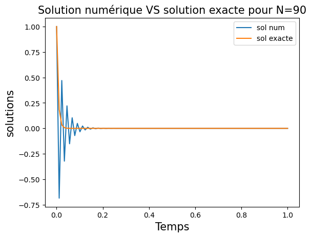

```python
# Initialisation
k = 150
r = 0
y0 = 1
t0= 0
tf= 1
N=90
t=np.linspace(t0,tf,N) # la subdivision de l'intervalle de temps
def Solution(k,r,t0,tf,y0,N):
    y=np.zeros(N) #initialisation du vecteur solution
    y[0]=y0 #condition initiale
    dt=(tf-t0)/(N-1) #longueur du pas de temps
    for i in range(1,N):
        y[i]=y[i-1]+dt*(-k*y[i-1]+r) #schéma d'Euler explicite
    return t,y

# Définition de la solution exacte

def Sol_exacte(k,r,t0,tf,y0,N):
    return (y0-r/k)*np.exp(-k*t)+r/k

# Définition de l'ordonnée du graphe de la solution exacte

y2=Sol_exacte(k,r,t0,tf,y0,N)

# Définition de l'ordonnée et l'abscisse du graphe de la solution numérique

t1,y1=Solution(k,r,t0,tf,y0,N)

plt.figure()
plt.plot(t1,y1,label="sol num")
plt.plot(t,y2,label="sol exacte")
plt.xlabel('Temps',size=15)
plt.ylabel('solutions',size=15)
plt.title('Solution numérique VS solution exacte pour N='+str(N),size=15)
plt.legend()
```

# Test pour deltat=1/160

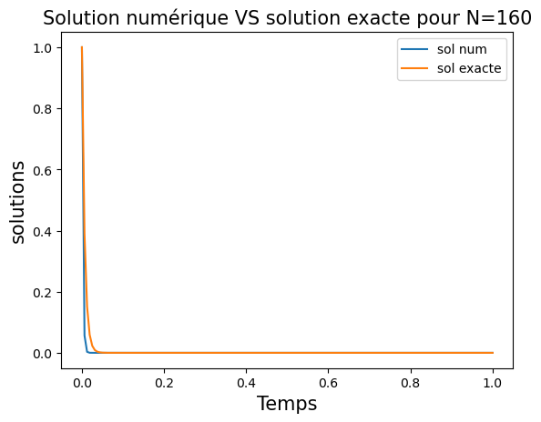

```python
# Initialisation
k = 150
r = 0
y0 = 1
t0= 0
tf= 1
N=160
t=np.linspace(t0,tf,N) # la subdivision de l'intervalle de temps
def Solution(k,r,t0,tf,y0,N):
    y=np.zeros(N) #initialisation du vecteur solution
    y[0]=y0 #condition initiale
    dt=(tf-t0)/(N-1) #longueur du pas de temps
    for i in range(1,N):
        y[i]=y[i-1]+dt*(-k*y[i-1]+r) #schéma d'Euler explicite
    return t,y

# Définition de la solution exacte

def Sol_exacte(k,r,t0,tf,y0,N):
    return (y0-r/k)*np.exp(-k*t)+r/k

# Définition de l'ordonnée du graphe de la solution exacte

y2=Sol_exacte(k,r,t0,tf,y0,N)

# Définition de l'ordonnée et l'abscisse du graphe de la solution numérique

t1,y1=Solution(k,r,t0,tf,y0,N)

plt.figure()
plt.plot(t1,y1,label="sol num")
plt.plot(t,y2,label="sol exacte")
plt.xlabel('Temps',size=15)
plt.ylabel('solutions',size=15)
plt.title('Solution numérique VS solution exacte pour N='+str(N),size=15)
plt.legend()
```

# 1_c) Trace de la marge de l'erreur

Tracer, en ´echelle log-log, le graphe de max(|yn −y(tn)|) pour 0≤n≤N (la norme infinie de l’erreur) en fonction du pas ∆t pour des valeurs de ∆t faible (par exemple entre 1/1500 et 1/1000). En deduire l’ordre de convergence du schema

```
le degré d'erreur est de [1.05518594 3.76390831]
```

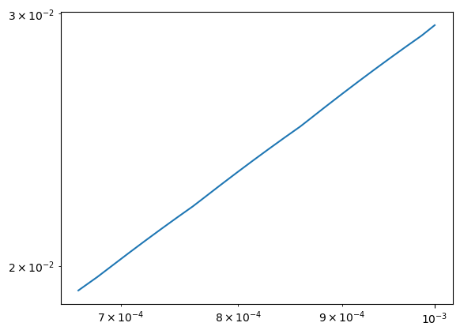

```python
# Initialisation
k = 150
r = 0
y0 = 1
t0= 0
tf= 1
N=1500

def Solution(k,r,t0,tf,y0,N):
    t=np.linspace(t0,tf,N) # la subdivision de l'intervalle de temps
    y=np.zeros(N) #initialisation du vecteur solution
    y[0]=y0 #condition initiale
    dt=(tf-t0)/(N-1) #longueur du pas de temps
    for i in range(1,N):
        y[i]=y[i-1]+dt*(-k*y[i-1]+r) #schéma d'Euler explicite
    return t,y

# Définition de la solution exacte

def Sol_exacte(k,r,t0,tf,y0,N): #solution exacte de l'équation
    return (y0-r/k)*np.exp(-k*t)+r/k



#Tracer du graphe

plt.figure()
err=np.zeros(500)
j=0
for i in range(1000,1500):
    t,y=Solution(k,r,t0,tf,y0,i)
    err[j]=np.max(np.abs(y-Sol_exacte(k,r,t0,tf,y0,i)))
    j=j+1
xerr=np.array([1/i  for i in range(1000,1500)])
plt.loglog(xerr,err,label='erreur')
print("le degré d'erreur est de", np.polyfit(np.log(xerr),np.log(err),1))
```

# Euler implicite avec les mêmes questions: y[n+1]=y[n]+h(f(t[n+1],y[n+1]))

```python
# Définition du la solution numérique

def Eulerimp(k,r,t0,tf,y0,N):
    t=np.linspace(t0,tf,N) # la subdivision de l'intervalle de temps
    y=np.zeros(N) #initialisation du vecteur solution
    y[0]=y0 #condition initiale
    dt=(tf-t0)/(N-1) #longueur du pas de temps
    for i in range(1,N):
        y[i]= (y[i-1]+r*dt)/(1+k*dt)#schéma d'Euler implicite
    return t,y


# Définition de la solution exacte

def Sol_exacte(k,r,t0,tf,y0,N):
    return (y0-r/k)*np.exp(-k*t)+r/k

# Définition de l'ordonnée du graphe de la solution exacte
```

# 2_b) Tracer sur un même graphe la solution exacte et l’approximation obtenue

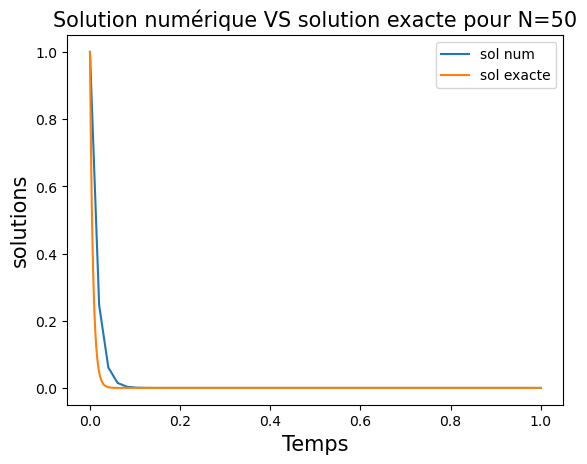

```python
# Initialisation
k = 150
r = 0
y0 = 1
t0= 0
tf= 1
N=50
def Eulerimp(k,r,t0,tf,y0,N):
    t=np.linspace(t0,tf,N) # la subdivision de l'intervalle de temps
    y=np.zeros(N) #initialisation du vecteur solution
    y[0]=y0 #condition initiale
    dt=(tf-t0)/(N-1) #longueur du pas de temps
    for i in range(1,N):
        y[i]= (y[i-1]+r*dt)/(1+k*dt)#schéma d'Euler implicite
    return t,y

# Définition de la solution exacte

def Sol_exacte(k,r,t0,tf,y0,N):
    return (y0-r/k)*np.exp(-k*t)+r/k

# Définition de l'ordonnée du graphe de la solution exacte

y2=Sol_exacte(k,r,t0,tf,y0,N)

# Définition de l'ordonnée et l'abscisse du graphe de la solution numérique

t3,y3=Eulerimp(k,r,t0,tf,y0,N)

plt.figure()
plt.plot(t3,y3,label="sol num")
plt.plot(t,y2,label="sol exacte")
plt.xlabel('Temps',size=15)
plt.ylabel('solutions',size=15)
plt.title('Solution numérique VS solution exacte pour N='+str(N),size=15)
plt.legend()
```

# Test pour deltat=1/70

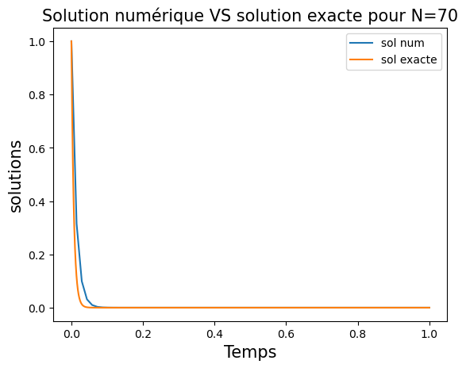

```python
# Initialisation
k = 150
r = 0
y0 = 1
t0= 0
tf= 1
N=70
def Eulerimp(k,r,t0,tf,y0,N):
    t=np.linspace(t0,tf,N) # la subdivision de l'intervalle de temps
    y=np.zeros(N) #initialisation du vecteur solution
    y[0]=y0 #condition initiale
    dt=(tf-t0)/(N-1) #longueur du pas de temps
    for i in range(1,N):
        y[i]= (y[i-1]+r*dt)/(1+k*dt)#schéma d'Euler implicite
    return t,y

# Définition de la solution exacte

def Sol_exacte(k,r,t0,tf,y0,N):
    return (y0-r/k)*np.exp(-k*t)+r/k

# Définition de l'ordonnée du graphe de la solution exacte

y2=Sol_exacte(k,r,t0,tf,y0,N)

# Définition de l'ordonnée et l'abscisse du graphe de la solution numérique

t3,y3=Eulerimp(k,r,t0,tf,y0,N)

plt.figure()
plt.plot(t3,y3,label="sol num")
plt.plot(t,y2,label="sol exacte")
plt.xlabel('Temps',size=15)
plt.ylabel('solutions',size=15)
plt.title('Solution numérique VS solution exacte pour N='+str(N),size=15)
plt.legend()
```

# Test pour deltat=1/90

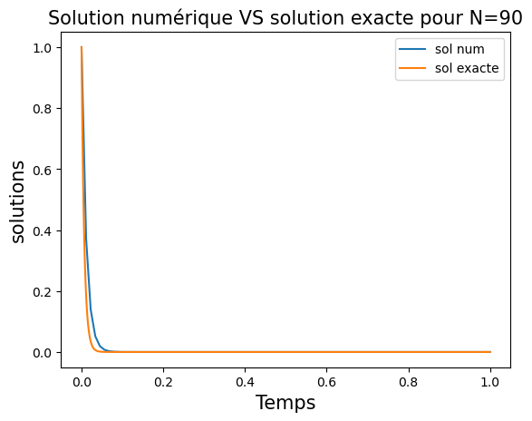

```python
# Initialisation
k = 150
r = 0
y0 = 1
t0= 0
tf= 1
N=90
def Eulerimp(k,r,t0,tf,y0,N):
    t=np.linspace(t0,tf,N) # la subdivision de l'intervalle de temps
    y=np.zeros(N) #initialisation du vecteur solution
    y[0]=y0 #condition initiale
    dt=(tf-t0)/(N-1) #longueur du pas de temps
    for i in range(1,N):
        y[i]= (y[i-1]+r*dt)/(1+k*dt)#schéma d'Euler implicite
    return t,y

# Définition de la solution exacte

def Sol_exacte(k,r,t0,tf,y0,N):
    return (y0-r/k)*np.exp(-k*t)+r/k

# Définition de l'ordonnée du graphe de la solution exacte

y2=Sol_exacte(k,r,t0,tf,y0,N)

# Définition de l'ordonnée et l'abscisse du graphe de la solution numérique

t3,y3=Eulerimp(k,r,t0,tf,y0,N)

plt.figure()
plt.plot(t3,y3,label="sol num")
plt.plot(t,y2,label="sol exacte")
plt.xlabel('Temps',size=15)
plt.ylabel('solutions',size=15)
plt.title('Solution numérique VS solution exacte pour N='+str(N),size=15)
plt.legend()
```

# Test pour deltat=1/160

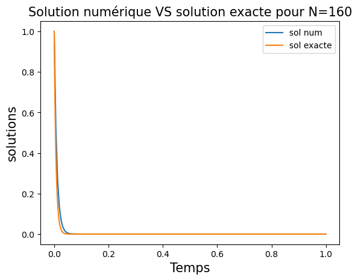

```python
# Initialisation
k = 150
r = 0
y0 = 1
t0= 0
tf= 1
N=160
def Eulerimp(k,r,t0,tf,y0,N):
    t=np.linspace(t0,tf,N) # la subdivision de l'intervalle de temps
    y=np.zeros(N) #initialisation du vecteur solution
    y[0]=y0 #condition initiale
    dt=(tf-t0)/(N-1) #longueur du pas de temps
    for i in range(1,N):
        y[i]= (y[i-1]+r*dt)/(1+k*dt)#schéma d'Euler implicite
    return t,y

# Définition de la solution exacte

def Sol_exacte(k,r,t0,tf,y0,N):
    return (y0-r/k)*np.exp(-k*t)+r/k

# Définition de l'ordonnée du graphe de la solution exacte

y2=Sol_exacte(k,r,t0,tf,y0,N)

# Définition de l'ordonnée et l'abscisse du graphe de la solution numérique

t3,y3=Eulerimp(k,r,t0,tf,y0,N)

plt.figure()
plt.plot(t3,y3,label="sol num")
plt.plot(t,y2,label="sol exacte")
plt.xlabel('Temps',size=15)
plt.ylabel('solutions',size=15)
plt.title('Solution numérique VS solution exacte pour N='+str(N),size=15)
plt.legend()
```

# 2_c) Trace de la marge de l'erreur

```
le degré d'erreur est de [0.95296964 2.93412911]
```

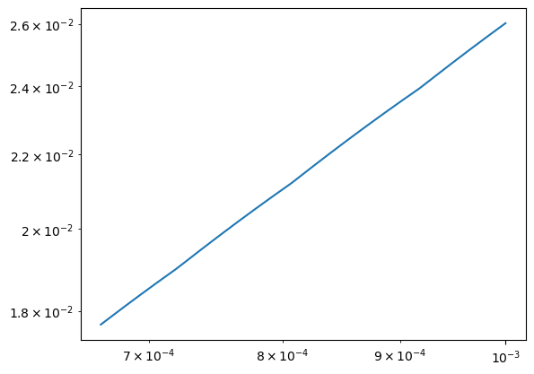

```python
#Tracer du graphe

plt.figure()
err=np.zeros(500)
j=0
for i in range(1000,1500):
    t,y=Eulerimp(k,r,t0,tf,y0,i)
    err[j]=np.max(np.abs(y-Sol_exacte(k,r,t0,tf,y0,i)))
    j=j+1
xerr=np.array([1/i  for i in range(1000,1500)])
plt.loglog(xerr,err,label='erreur')
print("le degré d'erreur est de", np.polyfit(np.log(xerr),np.log(err),1))
```

# Méthode de Crank-Nicolson: y[n+1]=y[n]+(h/2)[f(t[n],y[n])+f(t[n+1],y[n+1])]

```python
# Définition de la solution numérique
def CrankNic(k,r,t0,tf,y0,N):
    t=np.linspace(t0,tf,N+1) # la subdivision de l'intervalle de temps
    y=np.zeros(N+1) #initialisation du vecteur solution
    y[0]=y0 #condition initiale
    dt=(tf-t0)/(N) #longueur du pas de temps
    for i in range(1,N+1):
        y[i]= ((1-(k*dt)/2)/(1+(k*dt)/2))*y[i-1]+(r*dt/(1+(k*dt)/2))#schéma de Crank-Nicolson
    return t,y


# Définition de la solution exacte

def Sol_exacte(k,r,t0,tf,y0,N):
    return (y0-r/k)*np.exp(-k*t)+r/k
```

# Test pour delta=1/50

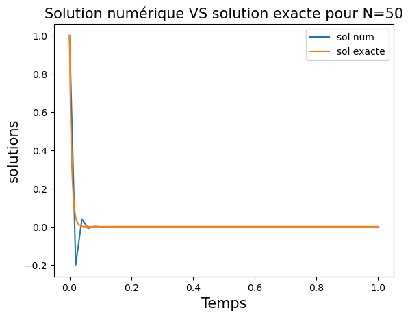

```python
# Initialisation
k = 150
r = 0
y0 = 1
t0= 0
tf= 1
N=50
# Définition de la solution numérique
def CrankNic(k,r,t0,tf,y0,N):
    t=np.linspace(t0,tf,N+1) # la subdivision de l'intervalle de temps
    y=np.zeros(N+1) #initialisation du vecteur solution
    y[0]=y0 #condition initiale
    dt=(tf-t0)/(N) #longueur du pas de temps
    for i in range(1,N+1):
        y[i]= ((1-(k*dt)/2)/(1+(k*dt)/2))*y[i-1]+(r*dt/(1+(k*dt)/2))#schéma de Crank-Nicolson
    return t,y


# Définition de la solution exacte

def Sol_exacte(k,r,t0,tf,y0,N):
    return (y0-r/k)*np.exp(-k*t)+r/k

# Définition de l'ordonnée du graphe de la solution exacte

y2=Sol_exacte(k,r,t0,tf,y0,N)

# Définition de l'ordonnée et l'abscisse du graphe de la solution numérique

t4,y4=CrankNic(k,r,t0,tf,y0,N)

plt.figure()
plt.plot(t4,y4,label="sol num")
plt.plot(t,y2,label="sol exacte")
plt.xlabel('Temps',size=15)
plt.ylabel('solutions',size=15)
plt.title('Solution numérique VS solution exacte pour N='+str(N),size=15)
plt.legend()
```

# Test pour deltat=1/70

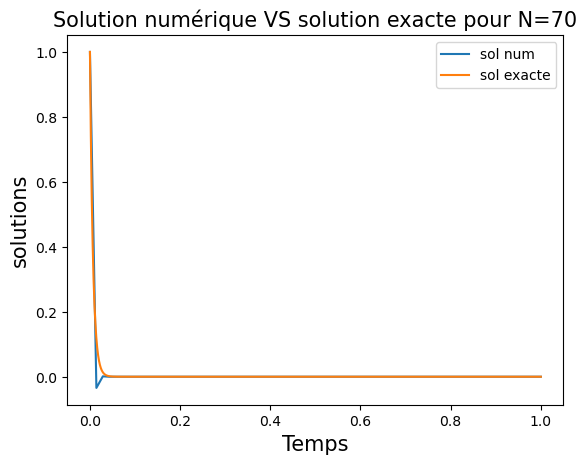

```python
# Initialisation
k = 150
r = 0
y0 = 1
t0= 0
tf= 1
N=70
# Définition de la solution numérique
def CrankNic(k,r,t0,tf,y0,N):
    t=np.linspace(t0,tf,N+1) # la subdivision de l'intervalle de temps
    y=np.zeros(N+1) #initialisation du vecteur solution
    y[0]=y0 #condition initiale
    dt=(tf-t0)/(N) #longueur du pas de temps
    for i in range(1,N+1):
        y[i]= ((1-(k*dt)/2)/(1+(k*dt)/2))*y[i-1]+(r*dt/(1+(k*dt)/2))#schéma de Crank-Nicolson
    return t,y


# Définition de la solution exacte

def Sol_exacte(k,r,t0,tf,y0,N):
    return (y0-r/k)*np.exp(-k*t)+r/k

# Définition de l'ordonnée du graphe de la solution exacte

y2=Sol_exacte(k,r,t0,tf,y0,N)

# Définition de l'ordonnée et l'abscisse du graphe de la solution numérique

t4,y4=CrankNic(k,r,t0,tf,y0,N)

plt.figure()
plt.plot(t4,y4,label="sol num")
plt.plot(t,y2,label="sol exacte")
plt.xlabel('Temps',size=15)
plt.ylabel('solutions',size=15)
plt.title('Solution numérique VS solution exacte pour N='+str(N),size=15)
plt.legend()
```

# Test pour delta=1/90

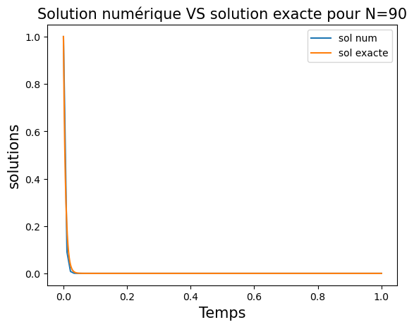

```python
# Initialisation
k = 150
r = 0
y0 = 1
t0= 0
tf= 1
N=90
# Définition de la solution numérique
def CrankNic(k,r,t0,tf,y0,N):
    t=np.linspace(t0,tf,N+1) # la subdivision de l'intervalle de temps
    y=np.zeros(N+1) #initialisation du vecteur solution
    y[0]=y0 #condition initiale
    dt=(tf-t0)/(N) #longueur du pas de temps
    for i in range(1,N+1):
        y[i]= ((1-(k*dt)/2)/(1+(k*dt)/2))*y[i-1]+(r*dt/(1+(k*dt)/2))#schéma de Crank-Nicolson
    return t,y


# Définition de la solution exacte

def Sol_exacte(k,r,t0,tf,y0,N):
    return (y0-r/k)*np.exp(-k*t)+r/k

# Définition de l'ordonnée du graphe de la solution exacte

y2=Sol_exacte(k,r,t0,tf,y0,N)

# Définition de l'ordonnée et l'abscisse du graphe de la solution numérique

t4,y4=CrankNic(k,r,t0,tf,y0,N)

plt.figure()
plt.plot(t4,y4,label="sol num")
plt.plot(t,y2,label="sol exacte")
plt.xlabel('Temps',size=15)
plt.ylabel('solutions',size=15)
plt.title('Solution numérique VS solution exacte pour N='+str(N),size=15)
plt.legend()
```

# Test pour delta=1/160

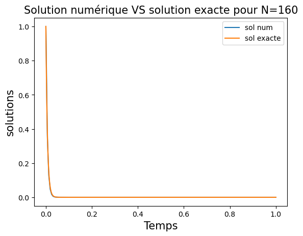

```python
# Initialisation
k = 150
r = 0
y0 = 1
t0= 0
tf= 1
N=160
# Définition de la solution numérique
def CrankNic(k,r,t0,tf,y0,N):
    t=np.linspace(t0,tf,N+1) # la subdivision de l'intervalle de temps
    y=np.zeros(N+1) #initialisation du vecteur solution
    y[0]=y0 #condition initiale
    dt=(tf-t0)/(N) #longueur du pas de temps
    for i in range(1,N+1):
        y[i]= ((1-(k*dt)/2)/(1+(k*dt)/2))*y[i-1]+(r*dt/(1+(k*dt)/2))#schéma de Crank-Nicolson
    return t,y


# Définition de la solution exacte

def Sol_exacte(k,r,t0,tf,y0,N):
    return (y0-r/k)*np.exp(-k*t)+r/k

# Définition de l'ordonnée du graphe de la solution exacte

y2=Sol_exacte(k,r,t0,tf,y0,N)

# Définition de l'ordonnée et l'abscisse du graphe de la solution numérique

t4,y4=CrankNic(k,r,t0,tf,y0,N)

plt.figure()
plt.plot(t4,y4,label="sol num")
plt.plot(t,y2,label="sol exacte")
plt.xlabel('Temps',size=15)
plt.ylabel('solutions',size=15)
plt.title('Solution numérique VS solution exacte pour N='+str(N),size=15)
plt.legend()
```

# 3_c) Trace de la marge de l'erreur

```
le degré d'erreur est de [2.00275052 6.55700903]
```

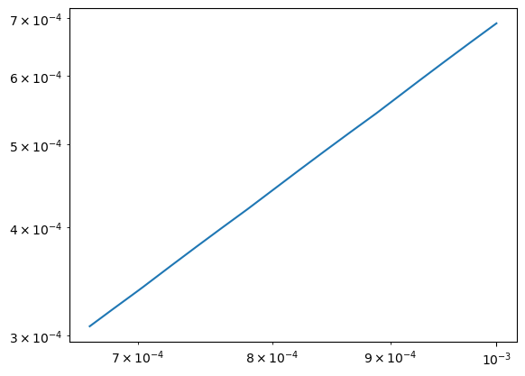

```python
#Tracer du graphe

plt.figure()
err=np.zeros(500)
j=0
for i in range(1000,1500):
    t,y=CrankNic(k,r,t0,tf,y0,i)
    err[j]=np.max(np.abs(y-Sol_exacte(k,r,t0,tf,y0,i)))
    j=j+1
xerr=np.array([1/i  for i in range(1000,1500)])
plt.loglog(xerr,err,label='erreur')
print("le degré d'erreur est de", np.polyfit(np.log(xerr),np.log(err),1))
```

# II. Equation de la Chaleur

## Résolution Numérique

### II.c)

Creer une fonction ResolutionExp qui prend en argument N, M et mu, tf et L. Cette fonction met en œuvre ce schema sur l’intervalle de temps I = [0, tf] et l’intervalle d’espace J =[0, L] avec u0(x):=sin(πx) (L sera suppose entier pour que les conditions de bords et initiale soient coherentes) et renvoie la discretisation T de I en N +1 points, la discretisation X de J en M + 2 points, et la matrice U ∈ MM+2,N+1(R).

```python
# Définition ResolutionExp qui prend en argument N, M et mu, tf et L
def ResolutionExp(N,M,mu, tf,L):
    T=np.linspace(0,tf,N+1)
    X=np.linspace(0,L,M+2)
    U=np.zeros((M+2,N+1))
    U[:,0]=np.sin(np.pi*X)
    dt=tf/N
    dx=L/(M+1)
    c=mu*dt/dx**2
    A=(1-2*c)*np.eye(M)
    B=c*np.eye(M,k=1)
    C=c*np.eye(M,k=-1)
    A=A+B+C
    V=U[1:M+1,0]
    for i in range(N):
        V=np.dot(A,V)
        U[1:M+1,i+1]=V
        #U[1:M+1,i+1]=U[1:M+1,i]+dt*mu*(U[:-2,i]-2*U[1:M+1,i]+U[2:,i])/dx**2
    return T, X, U
```

### II.d) Tracer de la solution numérique

Tracer la solution numerique obtenue avec les parametres suivants : tf = 0.5, L = 1, µ = 1, N = 110, M = 10.

```python
from matplotlib import cm
```

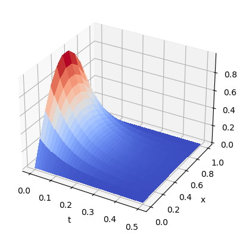

```python
Schema=ResolutionExp #pour Euler explicite
#Schema=ResolutionImp # pour Euler implicite
#Schema=Crank # pour Crank Nicolson
tf=0.5
L=1
mu=1
T,X,U=Schema(110,10,mu,tf,L);
TT,XX=np.meshgrid(T,X)
fig, ax = plt.subplots(subplot_kw={"projection": "3d"})
surf = ax.plot_surface(TT, XX, U, cmap=cm.coolwarm,linewidth=0, antialiased=False)
ax.set_xlabel('t')
ax.set_ylabel('x')
ax.set_zlabel('u')
```

Tracer la solution numerique obtenue avec les parametres suivants : tf = 0.5, L = 1, µ = 1, N = 110, M = 50.

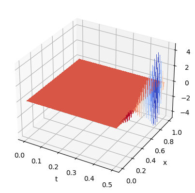

```python
Schema=ResolutionExp #pour Euler explicite
#Schema=ResolutionImp # pour Euler implicite
#Schema=Crank # pour Crank Nicolson
tf=0.5
L=1
mu=1
T,X,U=Schema(110,50,mu,tf,L);
TT,XX=np.meshgrid(T,X)
fig, ax = plt.subplots(subplot_kw={"projection": "3d"})
surf = ax.plot_surface(TT, XX, U, cmap=cm.coolwarm,linewidth=0, antialiased=False)
ax.set_xlabel('t')
ax.set_ylabel('x')
ax.set_zlabel('u')
```

#### Commentaire

Ces choix de N et M font tomber dt et dx en dehors de la zone de stabilité (condition CFL) du schéma REMARQUE : on aurait même pu prendre un maillage plus fin qu'en question 1.d, et pourtant avoir une solution numérique moins bonne ! Prendre par exemple M=30, N=300 : Dans ce cas le maillage est beaucoup plus fin, mais on a M**2>N, donc dt**2>dx**2/2 ==> instabilité

### II.f) tracer de la différence entre la solution solution exacte et son approximation obtenue pour M = 100, N = 30000, tf = 0.5.

Lorsque µ = 1 et L = 1, la solution exacte est donnée par u : (t, x)→ exp(−π^2*t)sin(πx).

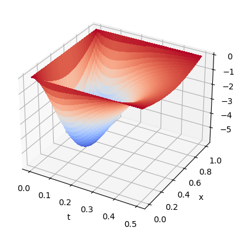

```python
#Définition de la solution exacte

def solution(t,x):
    u=np.exp(-np.pi*np.pi*t)*np.sin(np.pi*x)
    return u


# Tracé de la solution exacte

T,X,U=Schema(30000,100,1,tf,L);
TT,XX=np.meshgrid(T,X)
Uexac=solution(TT,XX)
fig, ax = plt.subplots(subplot_kw={"projection": "3d"})
surf = ax.plot_surface(TT, XX, U-Uexac, cmap=cm.coolwarm,linewidth=0, antialiased=False)
ax.set_xlabel('t')
ax.set_ylabel('x')
ax.set_zlabel('u')
```

La solution numérique est très proche de la solution exacte. Si on veut on peut regarder la différence On peut essayer d'augmenter M et N (tout en respectant la condition CFL, qui ici se traduit par N>=M**2)

## Reprise avec le shéma de EULER IMPLICITE

#### II.C)

Remarque : Schéma Implicite en temps. On écrit le schéma de la même façon en se plaçant au temps (n+1) au lieu de se placer au temps n dans l'approximation de la dérivée seconde en espace on obtient une relation du type u_i^n= combinaison linéaire des u_j^(n+1), avec j=i, i-1 et i+1 Sous forme matricielle, on a un schéma de la forme AU(n+1)=U(n) où U(n) est le vecteur des u_i^n On pourrait montrer que A est inversible et on a donc U(n+1)=inv(A)U(n)

```python
# Définition du Shéma Numérique d'Euler Implicite
def ResolutionImp(N,M,mu,tf,L):
    T=np.linspace(0,tf,N+1)
    X=np.linspace(0,L,M+2)
    U=np.zeros((M+2,N+1))
    U[:,0]=np.sin(np.pi*X)
    dt=tf/N
    dx=L/(M+1)
    c=mu*dt/dx**2
    A=(1+2*c)*np.eye(M)
    B=-c*np.eye(M,k=1)
    C=-c*np.eye(M,k=-1)
    A=A+B+C
    V=U[1:M+1,0]
    for i in range(N):
        V=np.linalg.solve(A,V)
        U[1:M+1,i+1]=V
    return T, X, U
```

#### II.d)

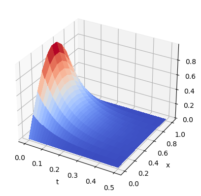

```python
Schema=ResolutionImp # pour Euler implicite
#Schema=Crank # pour Crank Nicolson
tf=0.5
L=1
mu=1
T,X,U=Schema(110,10,mu,tf,L);
TT,XX=np.meshgrid(T,X)
fig, ax = plt.subplots(subplot_kw={"projection": "3d"})
surf = ax.plot_surface(TT, XX, U, cmap=cm.coolwarm,linewidth=0, antialiased=False)
ax.set_xlabel('t')
ax.set_ylabel('x')
ax.set_zlabel('u')
```

On ne constate pas de problèmes d'instabilité (en fait on peut montrer que le schéma est stable pour tout choix de dt et dx)

#### II.e)

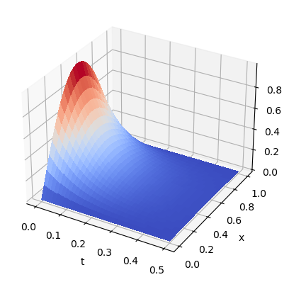

```python
Schema=ResolutionImp # pour Euler implicite
#Schema=Crank # pour Crank Nicolson
tf=0.5
L=1
mu=1
T,X,U=Schema(110,50,mu,tf,L);
TT,XX=np.meshgrid(T,X)
fig, ax = plt.subplots(subplot_kw={"projection": "3d"})
surf = ax.plot_surface(TT, XX, U, cmap=cm.coolwarm,linewidth=0, antialiased=False)
ax.set_xlabel('t')
ax.set_ylabel('x')
ax.set_zlabel('u')
```

#### II.f)

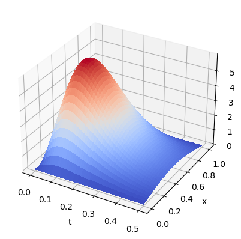

```python
Schema=ResolutionImp

#Définition de la solution exacte

def solution(t,x):
    u=np.exp(-np.pi*np.pi*t)*np.sin(np.pi*x)
    return u


# Tracé de la solution exacte

T,X,U=Schema(30000,100,1,tf,L);
TT,XX=np.meshgrid(T,X)
Uexac=solution(TT,XX)
fig, ax = plt.subplots(subplot_kw={"projection": "3d"})
surf = ax.plot_surface(TT, XX, U-Uexac, cmap=cm.coolwarm,linewidth=0, antialiased=False)
ax.set_xlabel('t')
ax.set_ylabel('x')
ax.set_zlabel('u')
```

## Reprise avec le shéma de Crank-Nicolson

#### II.c)

On obtient cette fois une relation de la forme A2 U(n+1)=A1 U(n)

```python
# Définition de la résolution numérique par Crank-Nicolson
def Crank(N,M,mu,tf,L):
    T=np.linspace(0,tf,N+1)
    X=np.linspace(0,L,M+2)
    U=np.zeros((M+2,N+1))
    U[:,0]=np.sin(np.pi*X)
    dt=tf/N
    dx=L/(M+1)
    c=mu*dt/dx**2
    c=c/2 # le facteur /2
    A1=(1-2*c)*np.eye(M) # la matrice qui apparait devant U(n)
    B1=c*np.eye(M,k=1)
    C1=c*np.eye(M,k=-1)
    A1=A1+B1+C1
    A2=(1+2*c)*np.eye(M) # la matrice devant U(n+1)
    B2=-c*np.eye(M,k=1)
    C2=-c*np.eye(M,k=-1)
    A2=A2+B2+C2
    V=U[1:M+1,0]
    for i in range(N):
        V=np.linalg.solve(A2,np.dot(A1,V))
        U[1:M+1,i+1]=V
    return T, X, U
```

#### II.d)

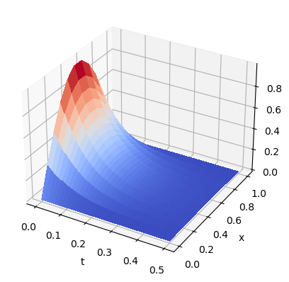

```python
Schema=Crank # pour Crank Nicolson
tf=0.5
L=1
mu=1
T,X,U=Schema(110,10,mu,tf,L);
TT,XX=np.meshgrid(T,X)
fig, ax = plt.subplots(subplot_kw={"projection": "3d"})
surf = ax.plot_surface(TT, XX, U, cmap=cm.coolwarm,linewidth=0, antialiased=False)
ax.set_xlabel('t')
ax.set_ylabel('x')
ax.set_zlabel('u')
```

#### II.e)

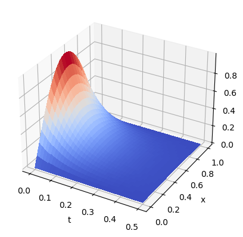

```python
Schema=Crank # pour Crank Nicolson
tf=0.5
L=1
mu=1
T,X,U=Schema(110,50,mu,tf,L);
TT,XX=np.meshgrid(T,X)
fig, ax = plt.subplots(subplot_kw={"projection": "3d"})
surf = ax.plot_surface(TT, XX, U, cmap=cm.coolwarm,linewidth=0, antialiased=False)
ax.set_xlabel('t')
ax.set_ylabel('x')
ax.set_zlabel('u')
```

#### II.f)

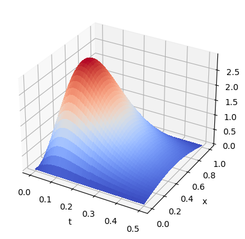

```python
Schema=Crank

#Définition de la solution exacte

def solution(t,x):
    u=np.exp(-np.pi*np.pi*t)*np.sin(np.pi*x)
    return u


# Tracé de la solution exacte

T,X,U=Schema(30000,100,1,tf,L);
TT,XX=np.meshgrid(T,X)
Uexac=solution(TT,XX)
fig, ax = plt.subplots(subplot_kw={"projection": "3d"})
surf = ax.plot_surface(TT, XX, U-Uexac, cmap=cm.coolwarm,linewidth=0, antialiased=False)
ax.set_xlabel('t')
ax.set_ylabel('x')
ax.set_zlabel('u')
```